# 2012 Presidential Campaign Donations

To start, I wanted to add a couple more variables to the dataset. I’ve added the gender of each canidate, as well as the party affilition.

```
## [1] 954661     21
```

```
## 'data.frame':    954661 obs. of  21 variables:
##  $ cmte_id          : Factor w/ 15 levels "C00410118","C00431171",..: 7 7 7 7 7 7 7 7 7 3 ...
##  $ cand_id          : Factor w/ 14 levels "P00003608","P20002523",..: 12 12 12 12 12 12 12 12 12 13 ...
##  $ cand_nm          : Factor w/ 14 levels "Bachmann, Michele",..: 8 8 8 8 8 8 8 8 8 7 ...
##  $ contbr_nm        : Factor w/ 199431 levels "''WILSON,'', ANIL",..: 88030 14995 110998 80250 36818 117746 2000 43756 149685 15658 ...
##  $ contbr_city      : Factor w/ 2497 levels "","/RANCHO PALOS /VER",..: 1706 1145 2037 2083 414 1258 166 1722 1853 2011 ...
##  $ contbr_st        : Factor w/ 1 level "CA": 1 1 1 1 1 1 1 1 1 1 ...
##  $ contbr_zip       : Factor w/ 115949 levels "","*9040","*9136",..: 28999 2933 36326 26534 107327 67728 91311 52377 113154 98439 ...
##  $ contbr_employer  : Factor w/ 68255 levels "","-","-SELF-",..: 48505 27832 64498 665 13167 56064 52825 16838 54086 48612 ...
##  $ contbr_occupation: Factor w/ 31407 levels "","-"," BUILDING TECH",..: 18016 22668 16243 11644 24375 24717 19690 3413 18942 23369 ...
##  $ contb_receipt_amt: num  100 20.1 100 25 250 ...
##  $ contb_receipt_dt : Factor w/ 662 levels "01-APR-11","01-APR-12",..: 113 113 113 113 113 113 113 113 113 585 ...
##  $ receipt_desc     : Factor w/ 37 levels "","ATTRIBUTION TO PARTNERS REQUESTED / REDESIGNATION REQUESTED",..: 1 1 1 1 1 1 1 1 1 1 ...
##  $ memo_cd          : Factor w/ 2 levels "","X": 1 1 1 1 1 1 1 1 1 1 ...
##  $ memo_text        : Factor w/ 261 levels "","*","* EARMARKED CONTRIBUTION: SEE BELOW",..: 1 1 1 1 1 1 1 1 1 1 ...
##  $ form_tp          : Factor w/ 3 levels "SA17A","SA18",..: 1 1 1 1 1 1 1 1 1 1 ...
##  $ file_num         : int  779227 779227 779227 779227 779227 779227 779227 779227 779227 756218 ...
##  $ tran_id          : Factor w/ 870697 levels "0000002","0000004-0001",..: 12867 12868 12869 12870 12871 12872 12873 12874 12875 41504 ...
##  $ election_tp      : Factor w/ 8 levels "","G2008","G2012",..: 7 7 7 7 7 7 7 7 7 7 ...
##  $ X                : logi  NA NA NA NA NA NA ...
##  $ canidate_gender  : Factor w/ 2 levels "F","M": 2 2 2 2 2 2 2 2 2 2 ...
##  $ party            : Factor w/ 2 levels "Democrat","Republican": 2 2 2 2 2 2 2 2 2 1 ...
```

```
##  [1] "Bachmann, Michele"              "Cain, Herman"
##  [3] "Gingrich, Newt"                 "Huntsman, Jon"
##  [5] "Johnson, Gary Earl"             "McCotter, Thaddeus G"
##  [7] "Obama, Barack"                  "Paul, Ron"
##  [9] "Pawlenty, Timothy"              "Perry, Rick"
## [11] "Roemer, Charles E. 'Buddy' III" "Romney, Mitt"
## [13] "Santorum, Rick"                 "Stein, Jill"
```

```
##       cmte_id            cand_id                    cand_nm
##  C00431445:724300   P80003338:724300   Obama, Barack    :724300
##  C00431171:193123   P80003353:193123   Romney, Mitt     :193123
##  C00495820: 18934   P80000748: 18934   Paul, Ron        : 18934
##  C00496497:  5572   P60003654:  5572   Gingrich, Newt   :  5572
##  C00496034:  5009   P20002721:  5009   Santorum, Rick   :  5009
##  C00497511:  1822   P20002978:  1882   Bachmann, Michele:  1882
##  (Other)  :  5901   (Other)  :  5841   (Other)          :  5841
##                     contbr_nm             contbr_city     contbr_st
##  HENRY, MICHELLE         :   284   LOS ANGELES  : 70394   CA:954661
##  GROVER-MCKAY, MALEAH    :   246   SAN FRANCISCO: 59294
##  BERKE, DAVID MICHAEL    :   237   SAN DIEGO    : 36955
##  BRYANT, REGINA          :   223   OAKLAND      : 24128
##  SCHABACKER, SCOTT D. MR.:   192   SAN JOSE     : 19193
##  RACCIO, KYLE            :   178   SACRAMENTO   : 17365
##  (Other)                 :953301   (Other)      :727332
##    contbr_zip                                   contbr_employer
##  94114  :  2858   RETIRED                               :187654
##  94110  :  2553   SELF-EMPLOYED                         :133867
##  94611  :  2221   NOT EMPLOYED                          : 66822
##  94117  :  2159   INFORMATION REQUESTED PER BEST EFFORTS: 20830
##  90046  :  1708   INFORMATION REQUESTED                 : 20063
##  94941  :  1657   (Other)                               :525132
##  (Other):941505   NA's                                  :   293
##                               contbr_occupation  contb_receipt_amt
##  RETIRED                               :211684   Min.   :-30000.0
##  ATTORNEY                              : 31519   1st Qu.:    25.0
##  HOMEMAKER                             : 22452   Median :    50.0
##  INFORMATION REQUESTED PER BEST EFFORTS: 19949   Mean   :   185.5
##  TEACHER                               : 18800   3rd Qu.:   100.0
##  (Other)                               :650185   Max.   : 30000.0
##  NA's                                  :    72
##   contb_receipt_dt                      receipt_desc    memo_cd
##  17-OCT-12: 30485                             :944375    :736576
##  02-NOV-12: 20899   Refund                    :  6783   X:218085
##  23-OCT-12: 18671   REDESIGNATION TO GENERAL  :   767
##  31-AUG-12: 17335   REDESIGNATION FROM PRIMARY:   749
##  31-OCT-12: 16285   REATTRIBUTION FROM SPOUSE :   391
##  06-SEP-12: 16264   REATTRIBUTION TO SPOUSE   :   391
##  (Other)  :834722   (Other)                   :  1205
```

[output cut: 9 more lines]

```
##  Min.   :723511   SA17.2691858:     4   G2012  :535321   Mode:logical
##  1st Qu.:810684   SA17.455267 :     4   P2012  :418419   NA's:954661
##  Median :821325   SA17.803913 :     4   O2012  :   651
##  Mean   :829038   SA17.1164123:     3   P2008  :   113
##  3rd Qu.:840327   SA17.512580 :     3          :    91
##  Max.   :992730   SA17.527780 :     3   G2008  :    54
##                   (Other)     :954640   (Other):    12
##  canidate_gender        party
##  F:  2068        Democrat  :724300
##  M:952593        Republican:230361
##
##
##
##
##
```

```
## [1] 944807     21
```

```
##       cmte_id            cand_id                    cand_nm
##  C00431445:717147   P80003338:717147   Obama, Barack    :717147
##  C00431171:191034   P80003353:191034   Romney, Mitt     :191034
##  C00495820: 18802   P80000748: 18802   Paul, Ron        : 18802
##  C00496497:  5400   P60003654:  5400   Gingrich, Newt   :  5400
##  C00496034:  4958   P20002721:  4958   Santorum, Rick   :  4958
##  C00497511:  1817   P20002978:  1876   Bachmann, Michele:  1876
##  (Other)  :  5649   (Other)  :  5590   (Other)          :  5590
##                      contbr_nm             contbr_city     contbr_st
##  HENRY, MICHELLE          :   272   LOS ANGELES  : 69441   CA:944807
##  GROVER-MCKAY, MALEAH     :   245   SAN FRANCISCO: 58573
##  BERKE, DAVID MICHAEL     :   237   SAN DIEGO    : 36613
##  BRYANT, REGINA           :   223   OAKLAND      : 23910
##  RACCIO, KYLE             :   178   SAN JOSE     : 19025
##  BEEGHLY, CHRISTINA D. MS.:   167   SACRAMENTO   : 17235
##  (Other)                  :943485   (Other)      :720010
##    contbr_zip                                   contbr_employer
##  94114  :  2818   RETIRED                               :186910
##  94110  :  2542   SELF-EMPLOYED                         :133423
##  94611  :  2199   NOT EMPLOYED                          : 66750
##  94117  :  2124   INFORMATION REQUESTED PER BEST EFFORTS: 20718
##  90046  :  1685   INFORMATION REQUESTED                 : 20049
##  94941  :  1635   (Other)                               :516664
##  (Other):931804   NA's                                  :   293
##                               contbr_occupation  contb_receipt_amt
##  RETIRED                               :210936   Min.   :    0.09
##  ATTORNEY                              : 31364   1st Qu.:   25.00
##  HOMEMAKER                             : 22263   Median :   50.00
##  INFORMATION REQUESTED PER BEST EFFORTS: 19838   Mean   :  193.54
##  TEACHER                               : 18787   3rd Qu.:  100.00
##  (Other)                               :641547   Max.   :30000.00
##  NA's                                  :    72
##   contb_receipt_dt                                   receipt_desc
##  17-OCT-12: 30445                                          :942683
##  02-NOV-12: 20847   REDESIGNATION FROM PRIMARY             :   749
##  23-OCT-12: 18614   REATTRIBUTION FROM SPOUSE              :   391
##  31-AUG-12: 17319   REATTRIBUTION / REDESIGNATION REQUESTED:   378
##  06-SEP-12: 16252   SEE REATTRIBUTION                      :   285
##  31-OCT-12: 16234   REDESIGNATION FROM GENERAL             :   198
##  (Other)  :825096   (Other)                                :   123
```

[output cut: 9 more lines]

```
##  Min.   :723511   SA17.770358:     3   G2012  :530030   Mode:logical
##  1st Qu.:810684   SA17.773369:     3   P2012  :414112   NA's:944807
##  Median :821325   SA17.774052:     3   O2012  :   651
##  Mean   :829001   SA17.775046:     3   P      :    10
##  3rd Qu.:840327   SA17.776842:     3   P2008  :     2
##  Max.   :992730   SA17.777239:     3   P2102  :     2
##                   (Other)    :944789   (Other):     0
##  canidate_gender        party
##  F:  2061        Democrat  :717147
##  M:942746        Republican:227660
##
##
##
##
##
```

# Univariate Analysis

### What is the structure of your dataset?

The structure of the dataset is a semi-transactional data showing each of the donations received for the 2012 presidential campaign. Overall there are 954,661 transactions in the dataset for 14 different candiates.

### What is/are the main feature(s) of interest in your dataset?

The main feature of this dataset is the donations, both the size and the quantity. I’ll be interested in looking at this broken down by candiate, party, gender, profession, and location. I’ll also be looking at what party and canidates were donated to broken down by area and profession.

### Did you create any new variables from existing variables in the dataset?

I added the gender of each canidate as well as the party. This should provide some interesting insight.

### Of the features you investigated, were there any unusual distributions? Did you perform any operations on the data to tidy, adjust, or change the form of the data? If so, why did you do this?

The contribution amount has an extremely long tail, with donations all the way up to $30,000, but a median of $50. The other thing that was surprising were the amount of “charged back” and “refunded” donations. For the sake of analyzing the size of contributions, I decided to omit these negative values and only focus on initial contributions. This reduced about 10,000 transactions and moved the mean contribution up to $193.54.

# Univariate Plots Section

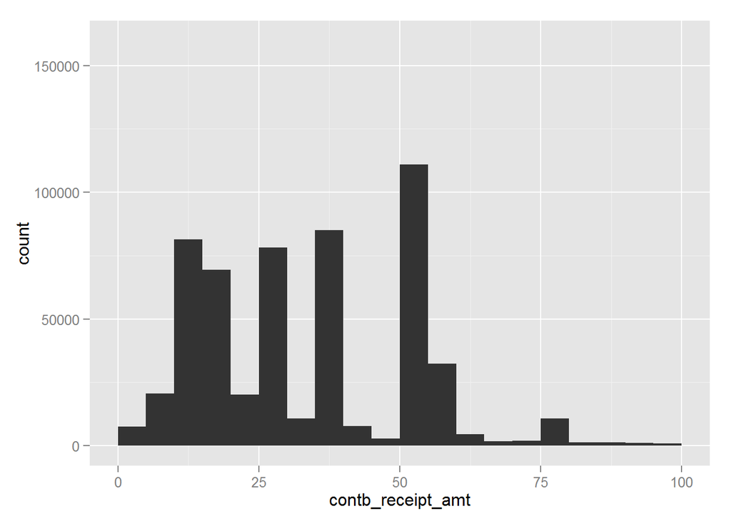

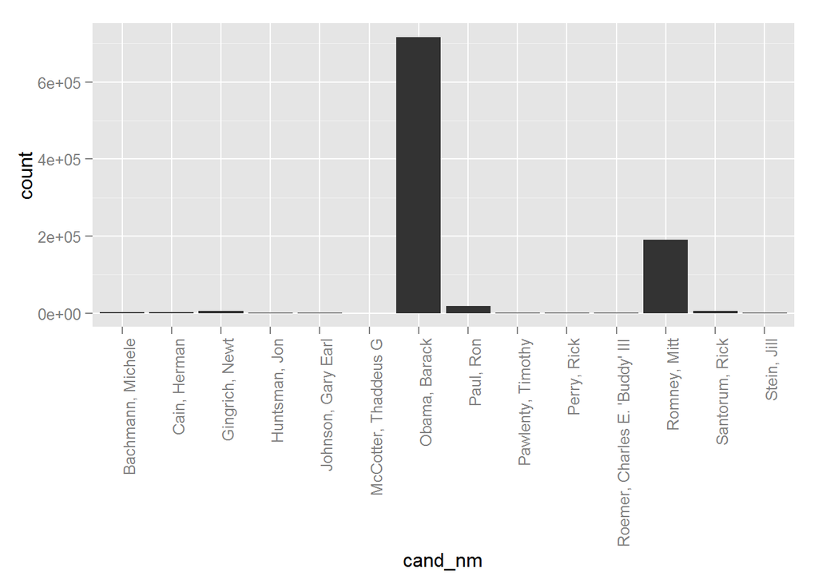

Just counting the donations from each canidate, you can see that Barack Obama received significantly more donations than the top Republican canidate, and that the top Republican canidate received significantly more donations than the next.

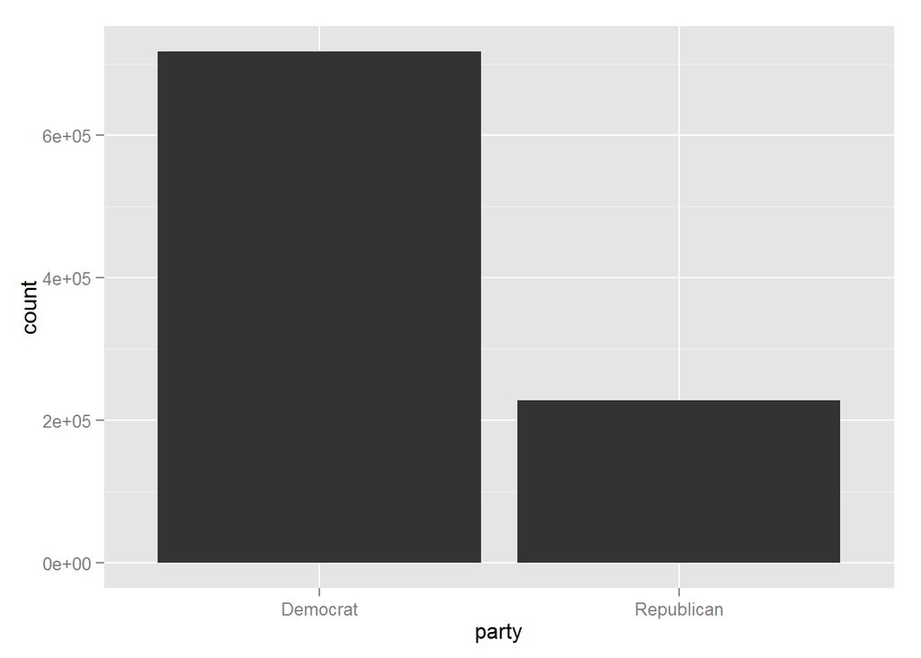

And here, grouping up all the Democratic and Republican contributions, we can see that there are over three times the amount of Democratic contributions as Republican.

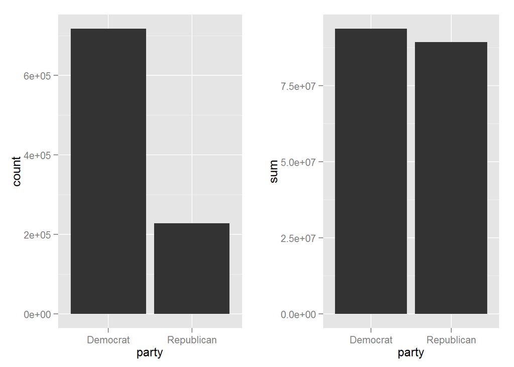

This is where things get interesting. Even though there are over three times the amount of Democratic contributions, the sum of those contributions is only 4 million dollars less, only about 5% less than the Democratic donations. When we look at the donation amount divided by the amount of the donations, we see that Republican canidates got $391.88 a donations, where the Democratic canidate only recieved $130.57 per donation. Let’s go back to the first plot of donation distribution and break it down by party.

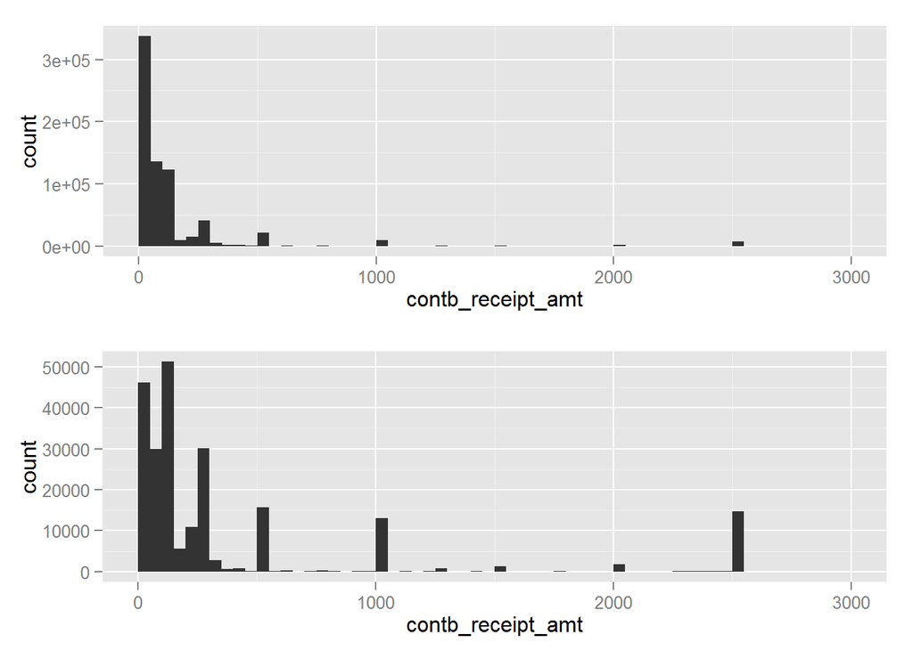

Here we’ve expanded the x-axis out to 3,000 as there are quite are many more Republican donations in the higher range. Where we have almost all of the Democratic donations bunched up less than $100, we can see significant spikes in donations of $1000 and $2500 for Republican canidates.

```
## Source: local data frame [2 x 4]
##
##   canidate_gender  count median     mean
##            (fctr)  (int)  (dbl)    (dbl)
## 1               F   2061    100 200.8052
## 2               M 942746     50 193.5202
```

Here, I’ve separated the donations made to the male canidates and the female canidates. Although the median is higher for female canidates, the mean is very similar. Unfortunately when dividing the data up like this it’s hard to look at the data made to female canidates as the sample size is so small (only 2,000 donations made to female canidates).

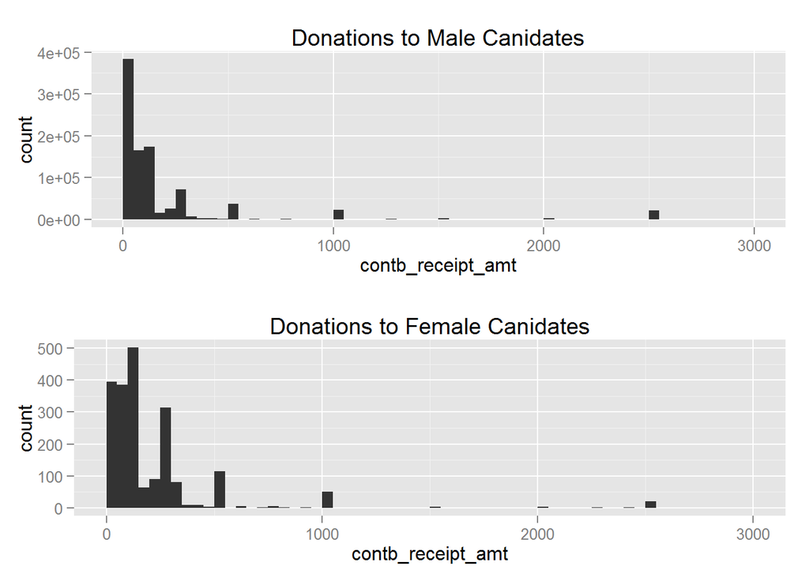

And here is the distribution for contributes made to each gender. Again, the distributions are slightly different, but with the sample size so small, it would be difficult to draw conclusions about contribution patterns for each canidate gender.

# Bivariate Plots Section

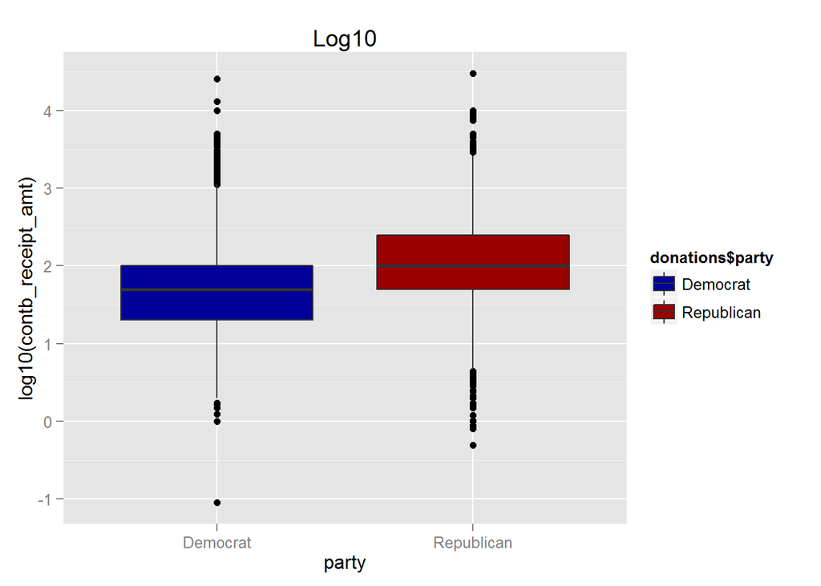

Next I decided to look at the donation amount per party. You can see the mean of donations to the Republican party is significantly greater than those made too the Democratic party, although there is a cluster of donations made that are much greater than the mean.

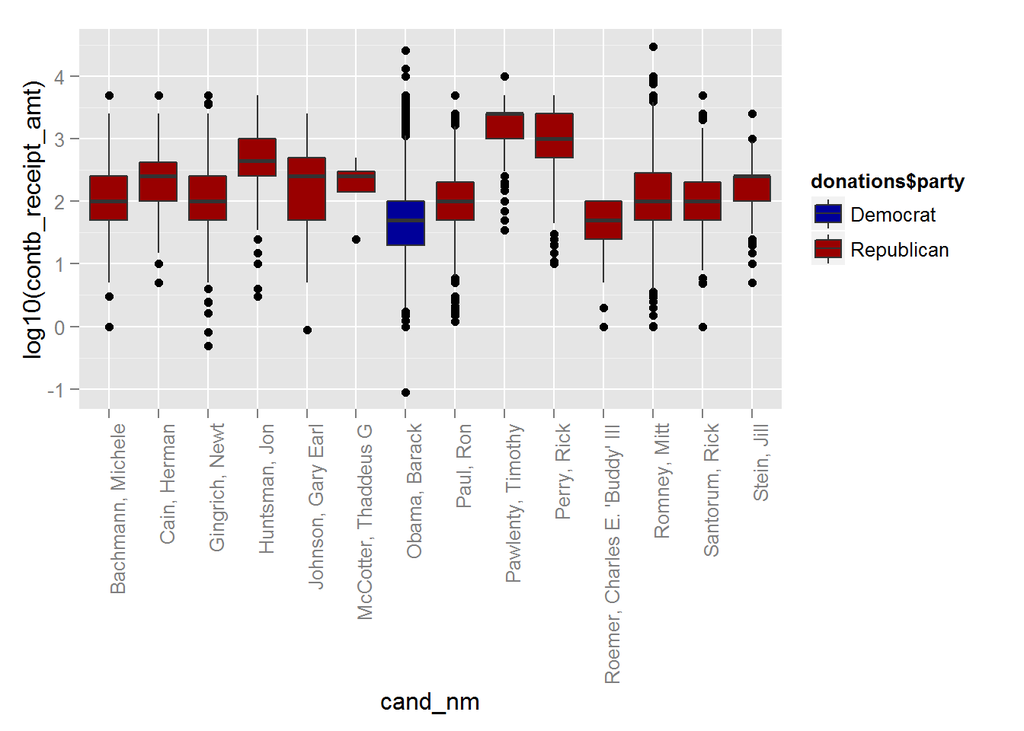

And here we can look at the donation amount per canidate. Almost every Republican canidate has a higher average donation amount than the only Democratic canidate, but the donations to Obama have a much higher variance due to the higher amount of donations.

```
## Source: local data frame [20 x 6]
##
##                         contbr_occupation      n median      mean   max
##                                    (fctr)  (int)  (dbl)     (dbl) (dbl)
## 1                                 RETIRED 210936     50 166.14609 13000
## 2                                ATTORNEY  31364    100 288.44990 25800
## 3                               HOMEMAKER  22263    100 391.27787  5000
## 4  INFORMATION REQUESTED PER BEST EFFORTS  19838    150 410.00905 10000
## 5                                 TEACHER  18787     35  81.14991  5000
## 6                   INFORMATION REQUESTED  18275    100 199.60467  5000
## 7                               PHYSICIAN  17099    100 244.81739 10000
## 8                                ENGINEER  14548     56 155.74870  5000
## 9                               PROFESSOR  12595     55 149.15563  5000
## 10                             CONSULTANT  11745     55 204.13017  5000
## 11                           NOT EMPLOYED  10216     35 109.11337  2655
## 12                                MANAGER   8206     50 164.76835  5000
## 13                                 WRITER   8046     50 172.28845  5000
## 14                                 LAWYER   7385    100 274.64810  3500
## 15                                  SALES   7147     50 136.47898  4500
## 16                          SELF-EMPLOYED   7045    100 287.96972  5000
## 17                      SOFTWARE ENGINEER   6782     56 155.34558  2515
## 18                                   NONE   6702    100 224.48244  5000
## 19                              PRESIDENT   4926    150 560.97539 10000
## 20                                STUDENT   4718     35 153.44707  2500
## Variables not shown: percentage (dbl)
```

Next I decided to filter out the top 10 occupations with the highest amount of donations for each canidate. I filtered out some of the categories as well as they were not actual occupations, but indicated people who had not responded.

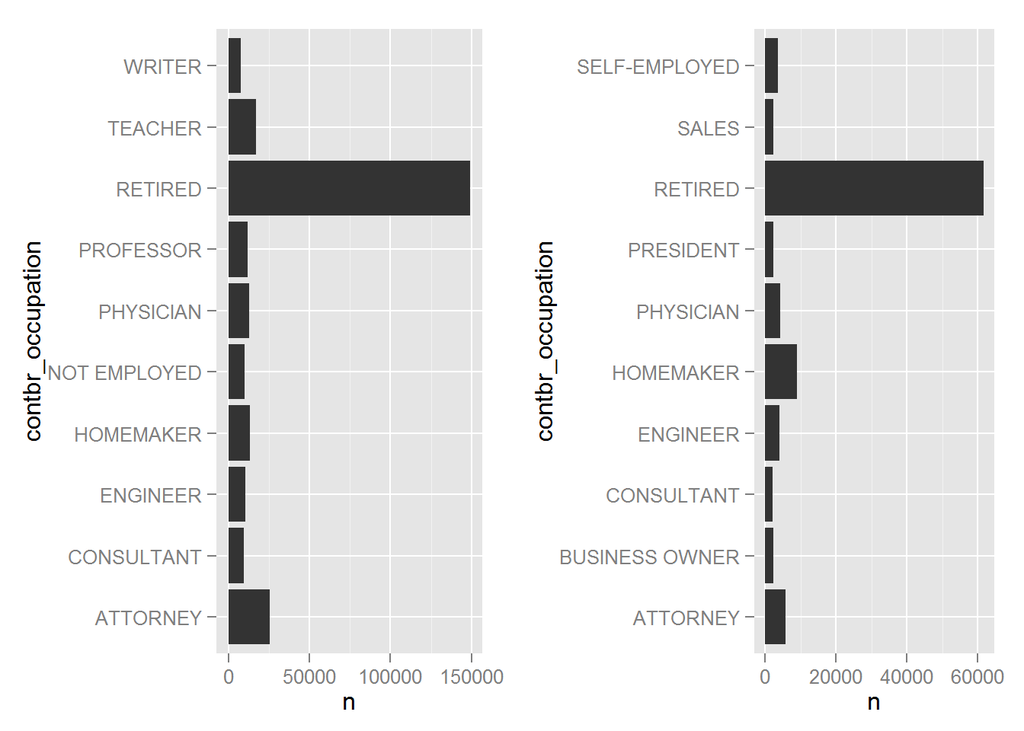

Here I’ve plotted out these donations and you can definitely see the overlap between the two parties. They both include Attorney, Consultants, Engineers, Homemakers, Physicians, and Retired people while Writers, Teachers, Professors and Unemployed prefered the Democractic party.

```
## Source: local data frame [20 x 6]
## Groups: contbr_occupation [17]
##
##                         contbr_occupation      party      n median
##                                    (fctr)     (fctr)  (int)  (dbl)
## 1                                 RETIRED   Democrat 149282     50
## 2                                 RETIRED Republican  61654    100
## 3                                ATTORNEY   Democrat  25678     95
## 4  INFORMATION REQUESTED PER BEST EFFORTS Republican  19838    150
## 5                   INFORMATION REQUESTED   Democrat  17368    100
## 6                                 TEACHER   Democrat  17188     35
## 7                               HOMEMAKER   Democrat  13176     50
## 8                               PHYSICIAN   Democrat  12724    100
## 9                               PROFESSOR   Democrat  12060     55
## 10                               ENGINEER   Democrat  10528     50
## 11                           NOT EMPLOYED   Democrat  10202     35
## 12                             CONSULTANT   Democrat   9638     50
## 13                              HOMEMAKER Republican   9087    200
## 14                                 WRITER   Democrat   7679     50
## 15                                   NONE Republican   6633    100
## 16                                 LAWYER   Democrat   6559    100
## 17                                MANAGER   Democrat   6266     50
## 18                      SOFTWARE ENGINEER   Democrat   5693     50
## 19                               ATTORNEY Republican   5686    250
## 20                                  SALES   Democrat   4711     35
## Variables not shown: mean (dbl), max (dbl)
```

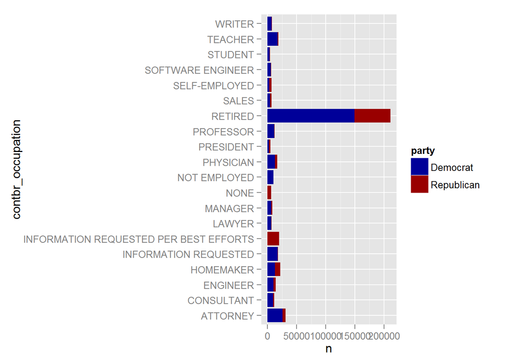

When I first generated this graph I was tempted to filter out certain factors of the occupation variable such as “Not Employed”, “Information Requested Per Best Efforts”, and “Not Employed” because they weren’t relevant to what I had been looking at, but I thought it was interested how these factors were unique to their respective parties. However the data was gathered, there must have been different options for each of the parties in how they were collecting the data.

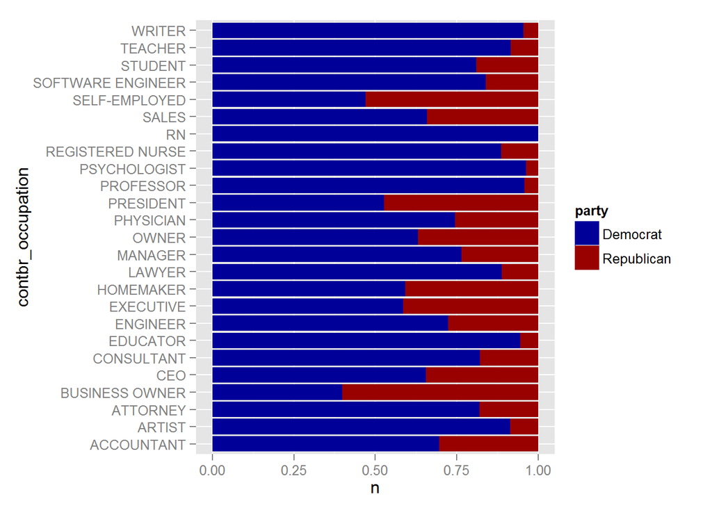

I’ve filtered out the retired canidates, as well as some of the other designations that were party specific to get a better look at the breakdown of each occupation and who they contributed for. I’ve also expanded out the canidates so we can take a look at a few more. It’s interesting to see how some occupations heavily favor a party (such as writers, psychologists, and artists).

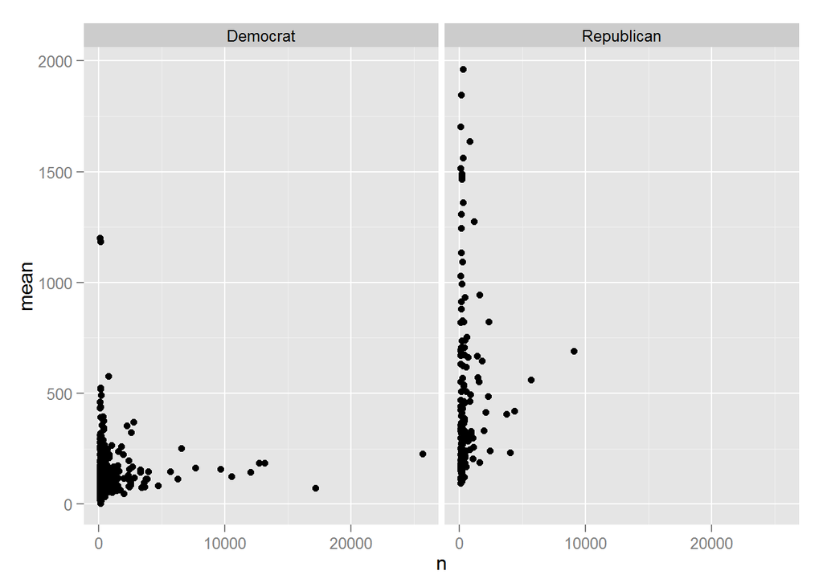

I’ve broken down the data here to plot out the mean donation amount plotted against the amount of donations. We can see what we’ve confirmed earlier in the analysis. The democratic party relies on many smaller donations, while the republican party relies on fewer, larger donations.

```
## Source: local data frame [3 x 5]
##
##       status      n median     mean   max
##        (chr)  (int)  (dbl)    (dbl) (dbl)
## 1   EMPLOYED 722951     50 202.7550 30000
## 2    RETIRED 210936     50 166.1461 13000
## 3 UNEMPLOYED  10848     35 111.5647  2655
```

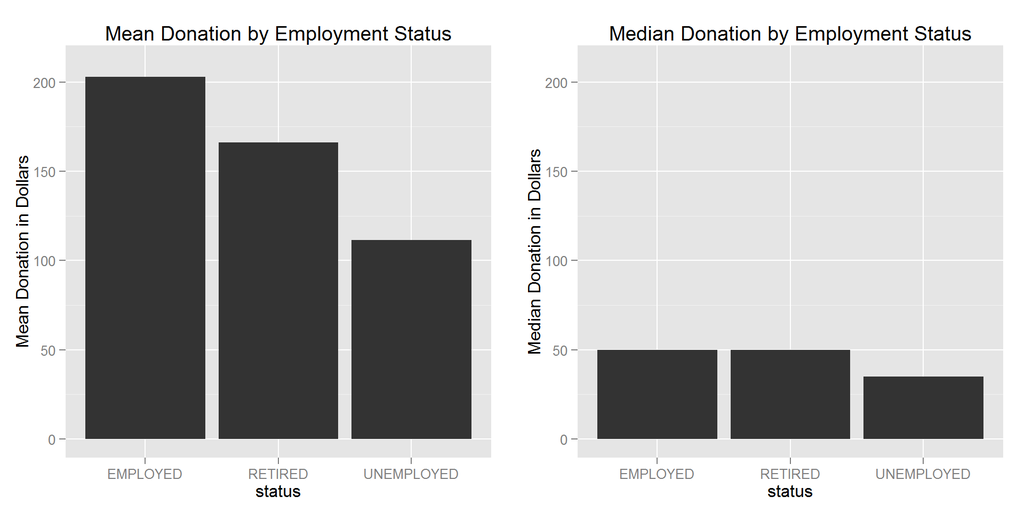

Here I’ve plotted out the differences between the different employment statuses, and again, there are not many surprises while looking at the data.

# Bivariate Analysis

### Talk about some of the relationships you observed in this part of the investigation. How did the feature(s) of interest vary with other features in the dataset?

Comparing donation amounts broken down by party was extremely interesting. The democractic party relies on many small donations while the Republican party receives few, but large donations, even per canidate.

### Did you observe any interesting relationships between the other features (not the main feature(s) of interest)?

Most of the features investigated here did not provided any meaningful insights. Many of the features behave exactly as one would expect.

### What was the strongest relationship you found?

The strongest relationship I’ve found so far is employment status. Those who are employed make bigger donations than those who are retired, and especially those who are unemployed.

# Multivariate Plots Section

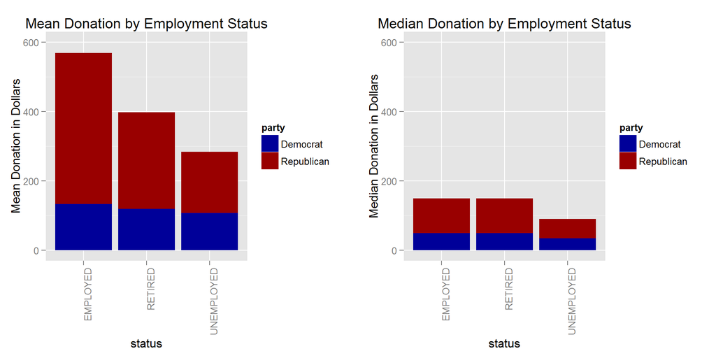

This is similar to a chart we looked at earlier, but now I’ve divided the bar by party. We can see the similar trend from before, that donations made to Republican canidates are significantly larger than those made to Democratic canidates. The only interesting thing when looking at the mean, is how much closer the donation amounts are between “employed” and “retired” donators in the Democratic party. We can see a drop off in the median donation of those “unemployed”.

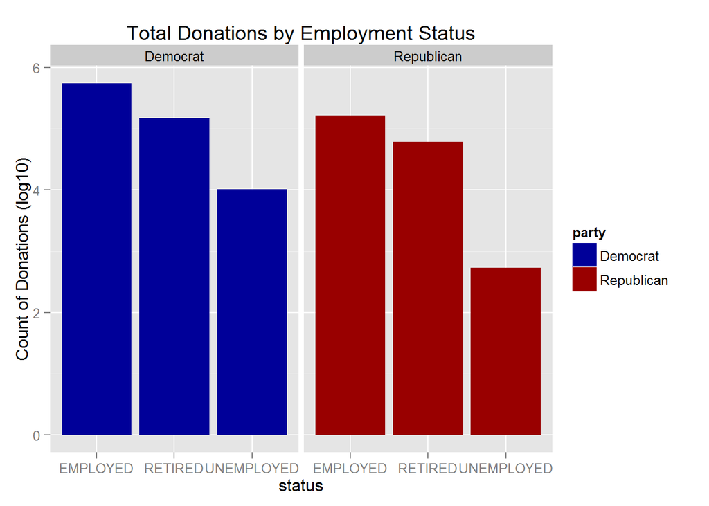

Here I’ve compared the amount of donations made to each party, broken down by employment status. The distributions are extremely similar, although there is a steeper drop off for Republican donations from unemployed donators compared to Democractic.

I next decided to plot out the donations on a map of California, and take a look at where the largest donations, and the highest average donations were coming from.

I added county data to the dataset using a city/county dataset I obtained from data.gov. This allowed me to assign a county to each of the cities found in the donations dataset, and then group up all donations by county.

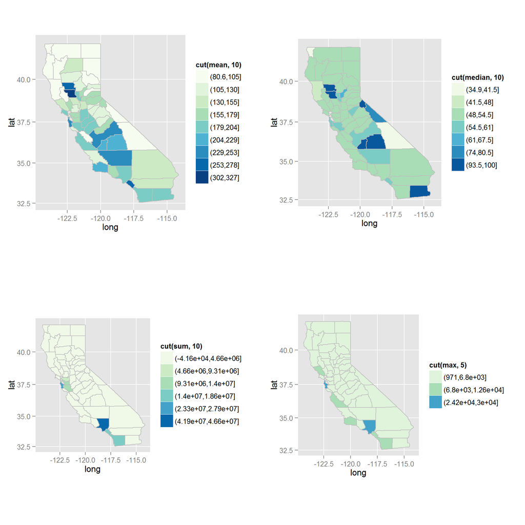

Here I’ve plotted out the median, mean, max, and total of donations made in each county. The map of the sum of the donations shows us what we already know, that the areas with the highest total of donations are large metropolotin areas such as Los Angeles and San Francisco. The max donations also come from these same areas. The difference between the mean and median plots are a little more interesting because they show the differences in how these donations come in from each county. The mean shows a trend of higher than average donations coming from central California, while the median shows higher medians from a handful of more inland counties.

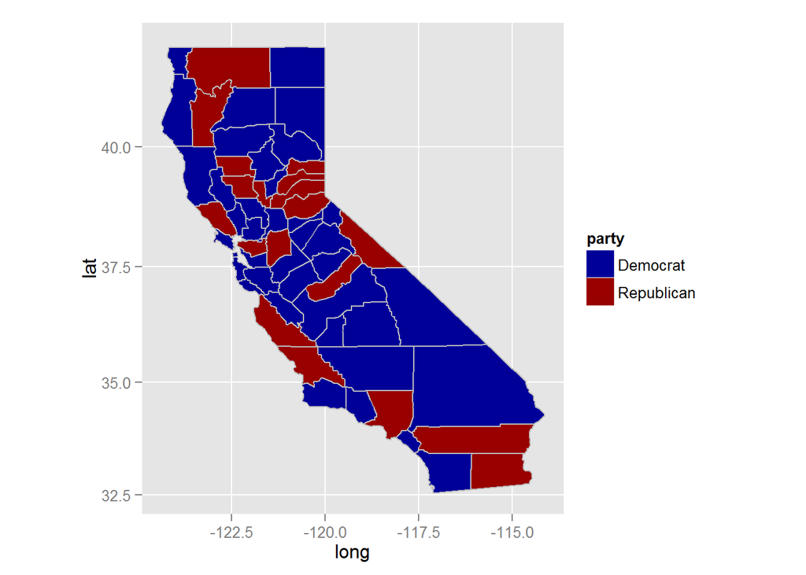

Here I’ve plotted out the party that each county has a higher number of donations to.

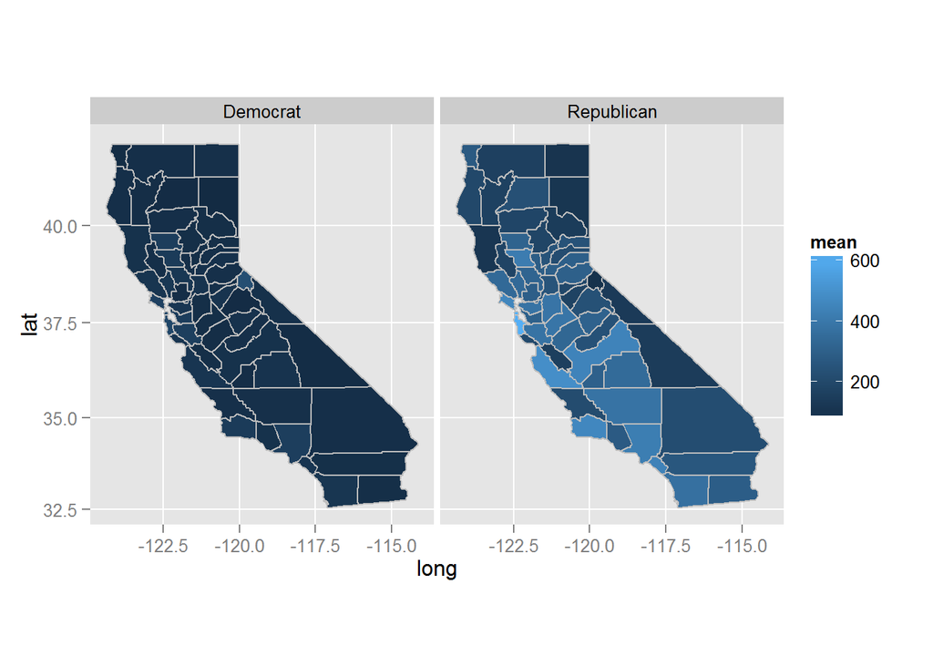

Here I’ve compared the mean donation amount for each county and split it up by party. Donations to Democratic canidates are spread fairly evenly throughout the country, while those made to Republican canidates have a much higher mean in the higher populated areas, such as San Francisco and Los Angeles.

# Multivariate Analysis

### Talk about some of the relationships you observed in this part of the investigation. Were there features that strengthened each other in terms of looking at your feature(s) of interest?

Breaking down the mean and median donations by party and employment status definitely showed some slight differences in the patterns in donation size from each party. It also helped highlight the difference in donation sizes from party to party.

### Were there any interesting or surprising interactions between features?

The most interesting feature from this section of the analysis is the effect employment status has on the donation size. Although it varies by donations to each party, there is a very clear drop off from employed, to retired, to unemployed.

### OPTIONAL: Did you create any models with your dataset? Discuss the strengths and limitations of your model.

No model was created.

# Final Plots and Summary

### Plot One

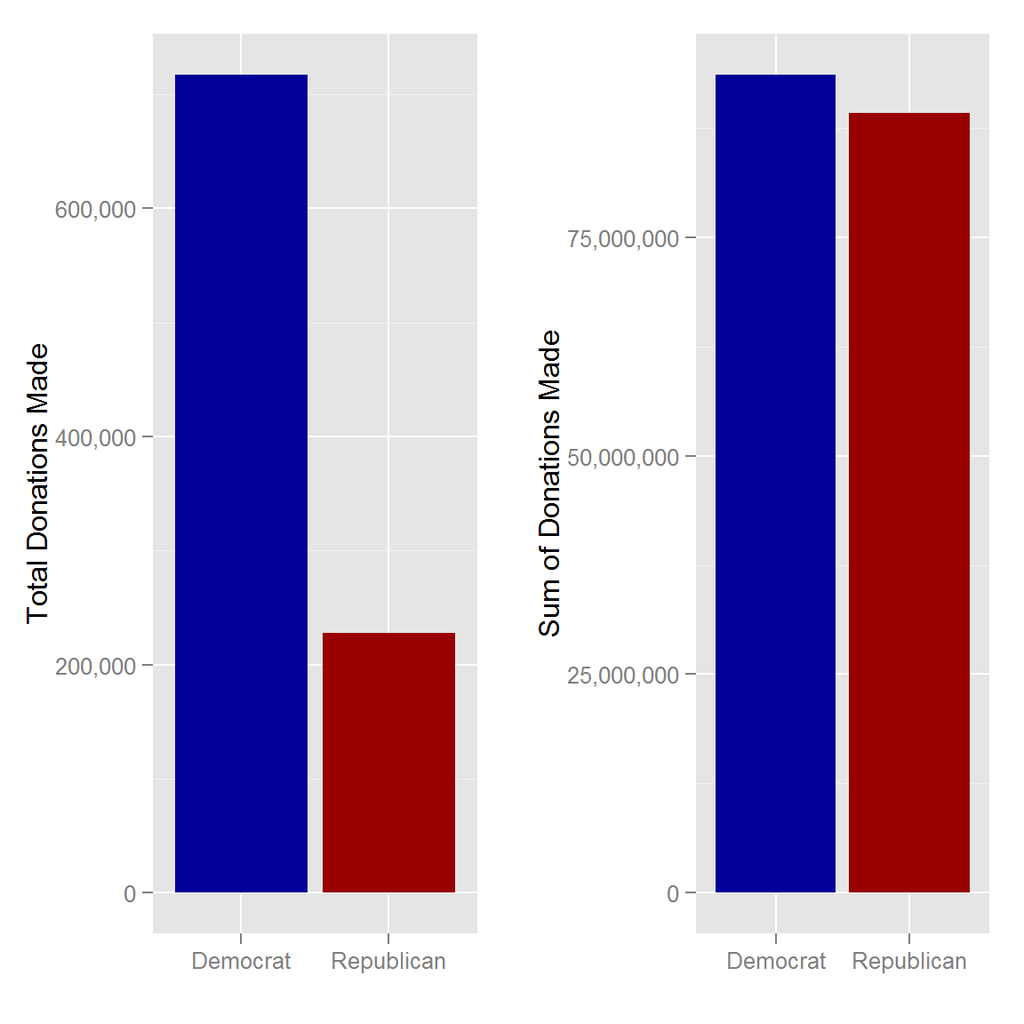

### Description One

This was the first interesting thing I came across in the dataset. I’ve plotted out the comparison between how many donation were made to each political party on the left, and then compared that to distribution of the sum of the donations on the right. Even though there were roughly 500,000 more donations made to the Democractic canidate, the Republicans raised nearly as much funding. This may to do with the amount of republican canidates, and each of them running their own campaigns and requesting contributions. Either way, it’s very interesting that donations made to the Republican party almost match those of the Democratic party despire having only about a quarter of donations made. This indicates that the donations made to the Republican party are much larger than those made to the Democractic. We’ll see more of this in the next chart.

### Plot Two

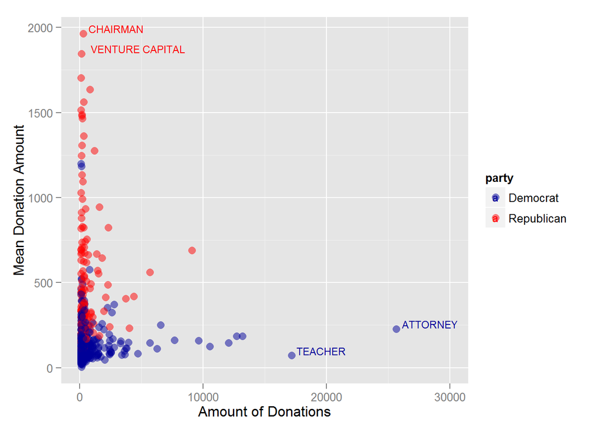

### Description Two

Here I’ve grouped together the average donation size for each occupation, and plotted them with the average donation per occupation, and the mean of each donation by occupation. We can see a similar trend to what we saw earlier, that the Repulican canidates make up the bulk of their donations with large contributions, while the Democratic party relies on many smaller donations. We can look at the largest donators to the Republican party, Chairmen and Venture Capitalists, and the occupations that donated the most, Attorneys and Teachers.

### Plot Three

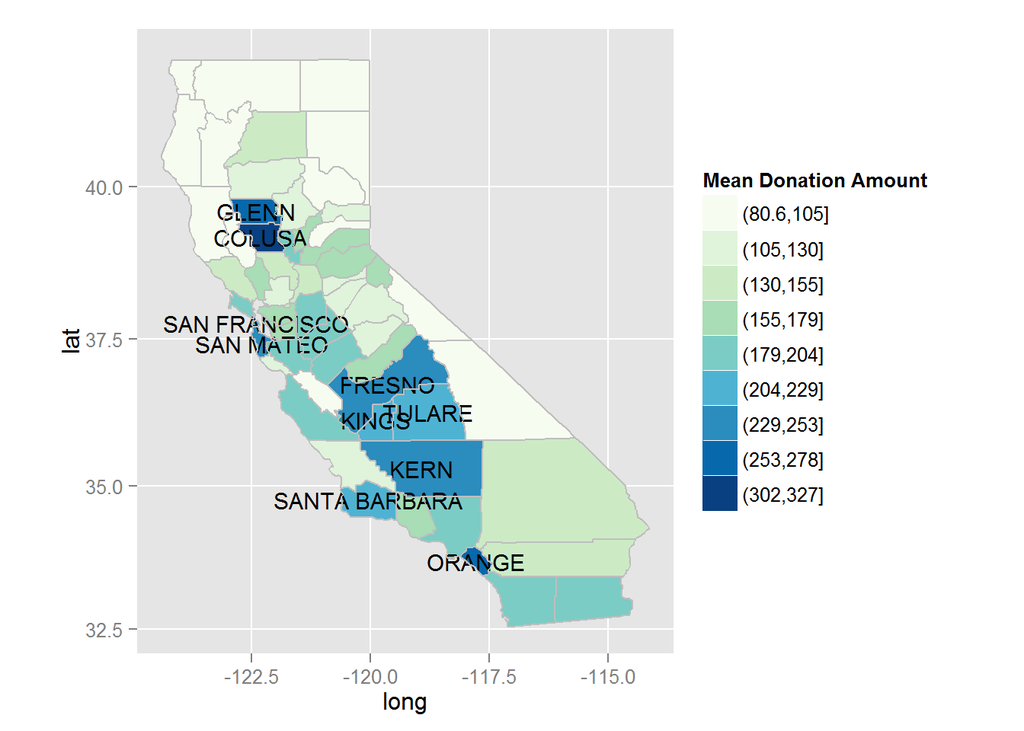

### Description Three

Here I’ve plotted out the mean donation amount made to all canidates and added the names of the 10 counties with the highest mean donation amount. There is a few distinct clusterings on the map. A large cluster exists in what is considered “Cental” California, another cluster in the San Franscisco Bay area, and another in the Northern part of the state. Many of these areas are considered wealthy areas such as Santa Barbara, Orange, and the San Francisco area so these don’t come as much surprise. The central counties with a higher mean are surprising, and this is where I think it would be beneficial to add more data to the dataset such as average income per county and county population. Knowing from experience that these areas are lower population, and lower income, it wouldn’t suprise me to see these area with fewer, but higher donations.

# Reflection